```python
# This is a cell to hide code snippets from displaying
# Any cell that contains the word "hide_me" will be hidden.

from IPython.display import HTML

hide_me = ''
HTML('''<script>
code_show=true;
function code_toggle() {
  if (code_show) {
    $('div.input').each(function(id) {
      if (id == 0 || $(this).html().indexOf('hide_me') > -1) {
        $(this).hide();
      }
    });
    $('div.output_prompt').css('opacity', 0);
  } else {
    $('div.input').each(function(id) {
      $(this).show();
    });
    $('div.output_prompt').css('opacity', 1);
  }
  code_show = !code_show
}
$( document ).ready(code_toggle);
</script>
<form action="javascript:code_toggle()"><input style="opacity:100" type="submit" value="Click here to toggle on/off the raw code."></form>''')
```

```python
hide_me

#!/usr/bin/python

import sys
import cPickle
import matplotlib.pyplot as plt
import numpy as np
sys.path.append("../tools/")

from feature_format import featureFormat, targetFeatureSplit
from tester import test_classifier, dump_classifier_and_data

### Load the dictionary containing the dataset
data_dict = cPickle.load(open("final_project_dataset.pkl", "r") )

# Preparing all features and data to test.

features_to_test = ['poi',
                    'bonus',
                    'salary',
                    'deferral_payments',
                    'deferred_income',
                    'director_fees',
                    'exercised_stock_options',
                    'expenses',
                    'total_payments',
                    'total_stock_value',
                    'from_messages',
                    'from_poi_to_this_person',
                    'from_this_person_to_poi',
                    'loan_advances',
                    'long_term_incentive',
                    'other',
                    'restricted_stock',
                    'restricted_stock_deferred',
                    'salary',
                    'shared_receipt_with_poi',
                    'to_messages'
                   ]
data_to_test = featureFormat(data_dict, features_to_test)
```

```python
hide_me
### Export pandas to csv, for GGpairs analysis in R
import pandas as pd
pd.set_option('display.max_columns', 30)
pd.set_option('display.width', None)
pd.set_option('display.max_colwidth', 0)

# We will use pandas many times in our project so turn this into a function:
def to_pandas(data_dict):
    df = pd.DataFrame(data_dict)
    df = df.convert_objects(convert_numeric=True)
    df = df.transpose()
    df.reset_index(level=0, inplace=True)
    # Renaming with df.rename(columns={'index': 'name'}) does not work
    # pandas bug??
    columns = list(df.columns)
    columns[0] = 'name'
    df.columns = columns
    return(df)
df = to_pandas(data_dict)
df.to_csv('dataset.csv')
```

# Identifying Fraud from Enron Email

by Jay Teguh Wijaya

## Abstract

In 2000, Enron was one of the largest companies in the United States. By 2002, it had collapsed into bankruptcy due to widespread corporate fraud. In the resulting Federal investigation, there was a significant amount of typically confidential information entered into public record, including tens of thousands of emails and detailed financial data for top executives.

This project attempts to predict the likelihood of someone being a suspect of Enron fraud conspiracy by looking at given dataset. We call the suspects Person of Interest (POI). The dataset contains insider pays to all Enron executives as well as emails sent through their company accounts, and their POI status.

We use machine learning to learn insider pays and emailing habits of POIs and non-POIs and see if we can find a pattern there, then use the model created to predict the likeliness of someone with a particular pattern of being a POI or not.

## 1. Introduction

*"The field of machine learning is concerned with the question of how to construct computer programs that automatically improve with experience."*

~Tom Mitchell

This document was initially intended for my personal use, that was as a documentation of the steps I took to build the prediction model for this problem set. After some thoughts I figure that there are maybe other people, both Machine Learning practitioners or curious minds who may benefit from this article. Hence I toned down the nerdiness of this article in hope for it to be more digestible by wider audience.

This is, however, still by nature a technical document, and it would be impossible to explain all the terminologies used without turning this into a book. For that purpose I created a [blog post](http://www.teguhwijaya.com/machine-learning/often-used-machine-learning-terms) explaining the terms used in this document. When you encountered an unfamiliar term while reading this document, you can head there for reference.

### Raw code toggle button

I added a small button on top of this page that will show the very code used in the analysis. Feel free to reuse the code I used here or make them as a point of reference in your own Machine Learning project.

## 2. Data Exploration

In the beginning of any machine learning project it is a good idea to explore the dataset to get a good sense on what we are dealing with.

In this section I present some summaries of our dataset:

```python
hide_me
print ', '.join(df.keys())
```

[output not shown]

I identified three main type of features in the dataset:

1. Insider pays like `bonus`, `salary`, `exercised_stock_options`, etc.
2. Emailing habits:
   - Number of emails sent: `from_messages`
   - Number of emails received: `to_messages`
   - Number of emails sent to POIs: `from_this_person_to_poi`
   - Number of emails received from POIs: `from_poi_to_this_person`
3. Our own features:
   - Receipts shared with poi: `shared_receipt_with_poi`
   - POI status as already known: `poi`

Here are some sample values:

```python
hide_me
heads = df.head(5)
heads
```

|  | name | bonus | deferral_payments | deferred_income | director_fees | email_address | exercised_stock_options | expenses | from_messages | from_poi_to_this_person | from_this_person_to_poi | loan_advances | long_term_incentive | other | poi | restricted_stock | restricted_stock_deferred | salary | shared_receipt_with_poi | to_messages | total_payments | total_stock_value |
| --- | --- | --- | --- | --- | --- | --- | --- | --- | --- | --- | --- | --- | --- | --- | --- | --- | --- | --- | --- | --- | --- | --- |
| 0 | ALLEN PHILLIP K | 4175000 | 2869717 | -3081055 | NaN | NaN | 1729541 | 13868 | 2195 | 47 | 65 | NaN | 304805 | 152 | 0 | 126027 | -126027 | 201955 | 1407 | 2902 | 4484442 | 1729541 |
| 1 | BADUM JAMES P | NaN | 178980 | NaN | NaN | NaN | 257817 | 3486 | NaN | NaN | NaN | NaN | NaN | NaN | 0 | NaN | NaN | NaN | NaN | NaN | 182466 | 257817 |
| 2 | BANNANTINE JAMES M | NaN | NaN | -5104 | NaN | NaN | 4046157 | 56301 | 29 | 39 | 0 | NaN | NaN | 864523 | 0 | 1757552 | -560222 | 477 | 465 | 566 | 916197 | 5243487 |
| 3 | BAXTER JOHN C | 1200000 | 1295738 | -1386055 | NaN | NaN | 6680544 | 11200 | NaN | NaN | NaN | NaN | 1586055 | 2660303 | 0 | 3942714 | NaN | 267102 | NaN | NaN | 5634343 | 10623258 |
| 4 | BAY FRANKLIN R | 400000 | 260455 | -201641 | NaN | NaN | NaN | 129142 | NaN | NaN | NaN | NaN | NaN | 69 | 0 | 145796 | -82782 | 239671 | NaN | NaN | 827696 | 63014 |

We can roughly tell from the above the type of each feature. `NaN` means `Not a Number`, usually to mark missing data values, but later we will see that in this case they should be replaced with `0`.

How many data points are we working with? And from them, how many persons-of-interest? Below are some information of that and the distribution of some values we might be interested in:

```python
hide_me
bypoi = df.groupby(['poi'])
print "number of features: ", len(df.keys()), "\n"
print bypoi['poi'].agg([len])
bypoi['bonus',
    'salary',
    'exercised_stock_options',
    'shared_receipt_with_poi',
    'loan_advances',
    'to_messages'].agg([np.mean])
```

```
number of features:  22

     len
poi
0    128
1    18
```

| poi | bonus mean | salary mean | exercised_stock_options mean | shared_receipt_with_poi mean | loan_advances mean | to_messages mean |
| --- | --- | --- | --- | --- | --- | --- |
| 0 | 2446776.348485 | 601152.500000 | 5390155.122222 | 1058.527778 | 28775000 | 2007.111111 |
| 1 | 2074999.937500 | 383444.882353 | 10463793.666667 | 1783.000000 | 81525000 | 2417.142857 |

Looks like there are quite a sparse number of pois compared to non-pois. The implication of this in machine learning is that we will end up with smaller number of targets to learn from. With that in mind, we will need to place more importance (known as weights in machine learning) in "poi" class.

```python
hide_me
desc = df.describe()
desc = desc.transpose()
desc
```

|  | count | mean | std | min | 25% | 50% | 75% | max |
| --- | --- | --- | --- | --- | --- | --- | --- | --- |
| bonus | 82 | 2374234.609756 | 10713327.969046 | 70000 | 431250.00 | 769375.0 | 1200000.00 | 97343619 |
| deferral_payments | 39 | 1642674.153846 | 5161929.973575 | -102500 | 81573.00 | 227449.0 | 1002671.50 | 32083396 |
| deferred_income | 49 | -1140475.142857 | 4025406.378506 | -27992891 | -694862.00 | -159792.0 | -38346.00 | -833 |
| director_fees | 17 | 166804.882353 | 319891.409747 | 3285 | 98784.00 | 108579.0 | 113784.00 | 1398517 |
| email_address | 0 | NaN | NaN | NaN | NaN | NaN | NaN | NaN |
| exercised_stock_options | 102 | 5987053.774510 | 31062006.568836 | 3285 | 527886.25 | 1310813.5 | 2547724.00 | 311764000 |
| expenses | 95 | 108728.915789 | 533534.814109 | 148 | 22614.00 | 46950.0 | 79952.50 | 5235198 |
| from_messages | 86 | 608.790698 | 1841.033949 | 12 | 22.75 | 41.0 | 145.50 | 14368 |
| from_poi_to_this_person | 86 | 64.895349 | 86.979244 | 0 | 10.00 | 35.0 | 72.25 | 528 |
| from_this_person_to_poi | 86 | 41.232558 | 100.073111 | 0 | 1.00 | 8.0 | 24.75 | 609 |
| loan_advances | 4 | 41962500.000000 | 47083208.701900 | 400000 | 1600000.00 | 41762500.0 | 82125000.00 | 83925000 |
| long_term_incentive | 66 | 1470361.454545 | 5942759.315498 | 69223 | 281250.00 | 442035.0 | 938672.00 | 48521928 |
| other | 93 | 919064.967742 | 4589252.907638 | 2 | 1215.00 | 52382.0 | 362096.00 | 42667589 |
| poi | 146 | 0.123288 | 0.329899 | 0 | 0.00 | 0.0 | 0.00 | 1 |
| restricted_stock | 110 | 2321741.136364 | 12518278.177383 | -2604490 | 254018.00 | 451740.0 | 1002369.75 | 130322299 |
| restricted_stock_deferred | 18 | 166410.555556 | 4201494.314703 | -7576788 | -389621.75 | -146975.0 | -75009.75 | 15456290 |
| salary | 95 | 562194.294737 | 2716369.154553 | 477 | 211816.00 | 259996.0 | 312117.00 | 26704229 |
| shared_receipt_with_poi | 86 | 1176.465116 | 1178.317641 | 2 | 249.75 | 740.5 | 1888.25 | 5521 |
| to_messages | 86 | 2073.860465 | 2582.700981 | 57 | 541.25 | 1211.0 | 2634.75 | 15149 |
| total_payments | 125 | 5081526.488000 | 29061716.401161 | 148 | 394475.00 | 1101393.0 | 2093263.00 | 309886585 |
| total_stock_value | 126 | 6773957.452381 | 38957772.732279 | -44093 | 494510.25 | 1102872.5 | 2949846.75 | 434509511 |

From above summary:

- Looks like we have 146 people / data points in our dataset.
- There are 128 non-POIs and 18 POIs in our dataset.
- There are 21 available features.
- The following features seems to lack data points:
  - director_fees
  - loan_advances
  - deferral_payments
  - deferred_income
  - restricted_stock_deferred but later we will find out that since NaN should be replaced by 0 they are not actually missing values, just need some small adjustment.

## 3. Dealing With Outliers

Outliers may or may not be useful in our prediction model. If they are invalid values, they need to be removed, but otherwise if they are correct, outliers are important information to have by a prediction model.

### 3.1. Finding outliers by visualizing the data

One way to find outliers is by visualizing the data, then use our human intuition to find suspicious looking values. Here are the histograms of all features:

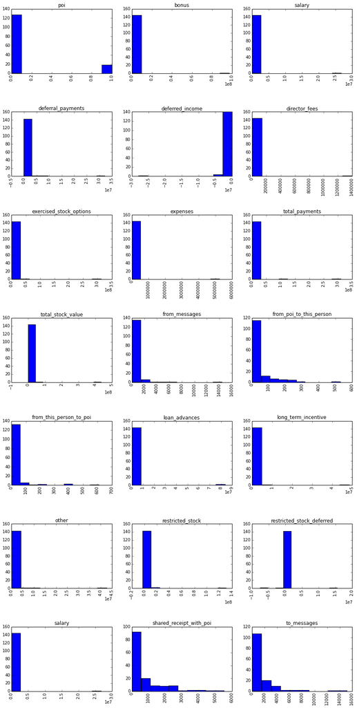

```python
hide_me
%pylab inline

# This creates a canvas of size 15 points width and 30 points height
fig = plt.figure(figsize=(15, 30))

for idx, feature in enumerate(features_to_test):
    # This means: Divide that canvas to 6 rows, 3 columns,
    # and at idx+1 position (since subplot is base-1), draw our plot.
    ax = plt.subplot(7,3, idx+1)

    plt.title(feature)
    plt.xticks(rotation='vertical')

    # hspace here sets space between rows.
    # http://matplotlib.org/api/figure_api.html#matplotlib.figure.SubplotParams
    plt.subplots_adjust(hspace=.6)

    ax.hist(data_to_test[:,idx])
```

Judging by the x-axis scales of some of our histograms like bonus, salary, etc., there seems to be some outliers in our dataset. We can find that out by seeing that the largest scale is 1e7(i.e. 10,000,000) times the rightmost value in some charts.

> **Note:** Ideally negative values found at `total_stock_value` and `restricted_stock` should have raised my suspicion, but for some reason, I did not see them in my analysis. That was alright, however, since as it turned out they are related to the outlier issues I found during the next section **Finding outliers by analyzing raw data** and they were corrected during that process.

To find out what the suspicious values are, I wrote a function to show five largest data to find our outliers, as well as showing if they are POI for some analysis. Let's try running it with feature `bonus`:

```python
hide_me
def show_largest_five(data_dict, features, feature):
    # What are the 5 largest points, sorted by x?
    print "5 largest", feature
    sorted_list = sorted(data_dict.iteritems(),
                 key=lambda (key, val): int(0 if val[feature] == 'NaN' else val[feature]), reverse=True)[0:5]
    print [(i[0]+ "(" + ('poi' if i[1]['poi'] else 'not poi') + "): "+ str(i[1][feature])) for i in sorted_list]
```

```python
hide_me
show_largest_five(data_dict, features_to_test, 'bonus')
```

```
5 largest bonus
['TOTAL(not poi): 97343619', 'LAVORATO JOHN J(not poi): 8000000', 'LAY KENNETH L(poi): 7000000', 'SKILLING JEFFREY K(poi): 5600000', 'BELDEN TIMOTHY N(poi): 5249999']
```

**TOTAL** is clearly an outlier, and it makes sense that it caused many feature values skewed far to the right. In this case this data point needs to be removed from our dataset.

```python
hide_me
if 'TOTAL' in data_dict:
    del data_dict['TOTAL']
```

There are still some suspicious values on `exercised_stock_options`, `loan_advances`, `other`, `restricted_stock`, and `restricted_stock_deferred`. Let's get 5 largest values off them.

```python
hide_me
show_largest_five(data_dict, features_to_test, 'exercised_stock_options')
show_largest_five(data_dict, features_to_test, 'loan_advances')
show_largest_five(data_dict, features_to_test, 'other')
show_largest_five(data_dict, features_to_test, 'restricted_stock')
show_largest_five(data_dict, features_to_test, 'restricted_stock_deferred')
```

```
5 largest exercised_stock_options
['LAY KENNETH L(poi): 34348384', 'HIRKO JOSEPH(poi): 30766064', 'RICE KENNETH D(poi): 19794175', 'SKILLING JEFFREY K(poi): 19250000', 'PAI LOU L(not poi): 15364167']
5 largest loan_advances
['LAY KENNETH L(poi): 81525000', 'FREVERT MARK A(not poi): 2000000', 'PICKERING MARK R(not poi): 400000', 'METTS MARK(not poi): NaN', 'BAXTER JOHN C(not poi): NaN']
5 largest other
['LAY KENNETH L(poi): 10359729', 'FREVERT MARK A(not poi): 7427621', 'MARTIN AMANDA K(not poi): 2818454', 'BAXTER JOHN C(not poi): 2660303', 'SHERRIFF JOHN R(not poi): 1852186']
5 largest restricted_stock
['LAY KENNETH L(poi): 14761694', 'WHITE JR THOMAS E(not poi): 13847074', 'PAI LOU L(not poi): 8453763', 'SKILLING JEFFREY K(poi): 6843672', 'FREVERT MARK A(not poi): 4188667']
5 largest restricted_stock_deferred
['BHATNAGAR SANJAY(not poi): 15456290', 'BELFER ROBERT(not poi): 44093', 'METTS MARK(not poi): NaN', 'BAXTER JOHN C(not poi): NaN', 'ELLIOTT STEVEN(not poi): NaN']
```

From the above, I conclude the following

- Except for `restricted_stock_deferred`, they looked normal enough to use in our classifiers, as we can see that the largest values belongs to a POI.
- `restricted_stock_deferred` could be an outlier, but we can't really tell at the moment, since it is possible, though perhaps unlikely, that that person does have that much difference compared to others. One way to find this out for sure is by comparing our dataset with the raw data which I do in the next section.

### 3.2. Finding outliers by analyzing raw data

In this project we are lucky enough to have a pdf file `enron61702insiderpay.pdf` containing insider pay information of all people in the dataset.

Here in this section I will explain the most optimal method to validate and correct our dataset from raw data.

> **Noob mistake:** Initially, I mistakenly not looking into the pdf file at all, and when trying to find a way to combine the features, I see that some features can be combined into `total_payments`, while some others into `total_stock_value`. I would have saved quite a bit of time by directly reading the pdf first then reconfirm our dataset with the grouping formula as I have written here, but beginner's gotta learn!

#### Find how the features correlate

From the pdf, we can find that there are two groups of insider pays:

1. `total_payments`, which is a combination of:
   - `salary`
   - `bonus`
   - `director_fees`
   - `deferral_payments`
   - `deferred_income`
   - `loan_advances`
   - `long_term_incentive`
   - `expenses`
   - `other`
   - `salary`
2. `total_stock_value`, a combination of:
   - `restricted_stock`
   - `exercised_stock_options`
   - `restricted_stock_deferred`

By having this knowledge, we know that we can confirm if the features' values are correct by running a small script that calculates `total_payments` and `total_stock_value` from other features, and report to us data points where the calculations were off.

First we do it for `total_payments`, here is the report:

```python
hide_me
# dataframe to check total_payments
df2 = pd.DataFrame()

df = df.fillna(0)
df2['name'] = df['name']
df2['combined'] = (
    df['bonus'] +
    df['director_fees'] +
    df['deferral_payments'] +
    df['deferred_income'] +
    df['loan_advances'] +
    df['long_term_incentive'] +
    df['expenses'] +
    df['other'] +
    df['salary']
)
df2['total_payments'] = df['total_payments']
df2['equals?'] = (df2['combined'] == df2['total_payments'])
df2['poi'] = df['poi']
print df2.head(5)
print np.sum(df2['equals?']), " out of ", len(df2)
print "Total difference between combined and total_payments: ", (np.sum(df2['total_payments']) - np.sum(df2['combined']))
print "\n"
print "Which data points are different?"
print df2[df2['equals?'] == False]
df[df['name'].isin(df2[df2['equals?'] == False]['name'].tolist())]
```

```
                 name  combined  total_payments equals?  poi
0  ALLEN PHILLIP K     4484442   4484442         True    0
1  BADUM JAMES P       182466    182466          True    0
2  BANNANTINE JAMES M  916197    916197          True    0
3  BAXTER JOHN C       5634343   5634343         True    0
4  BAY FRANKLIN R      827696    827696          True    0
144  out of  146
Total difference between combined and total_payments:  15382277.0


Which data points are different?
                name  combined  total_payments equals?  poi
8   BELFER ROBERT    -99215     102500          False   0
11  BHATNAGAR SANJAY  275728    15456290        False   0
```

|  | name | bonus | deferral_payments | deferred_income | director_fees | email_address | exercised_stock_options | expenses | from_messages | from_poi_to_this_person | from_this_person_to_poi | loan_advances | long_term_incentive | other | poi | restricted_stock | restricted_stock_deferred | salary | shared_receipt_with_poi | to_messages | total_payments | total_stock_value |
| --- | --- | --- | --- | --- | --- | --- | --- | --- | --- | --- | --- | --- | --- | --- | --- | --- | --- | --- | --- | --- | --- | --- |
| 8 | BELFER ROBERT | 0 | -102500 | 0 | 3285 | 0 | 3285 | 0 | 0 | 0 | 0 | 0 | 0 | 0 | 0 | 0 | 44093 | 0 | 0 | 0 | 102500 | -44093 |
| 11 | BHATNAGAR SANJAY | 0 | 0 | 0 | 137864 | 0 | 2604490 | 0 | 29 | 0 | 1 | 0 | 0 | 137864 | 0 | -2604490 | 15456290 | 0 | 463 | 523 | 15456290 | 0 |

We found two incorrect entries. Let's now look into combining stock related values:

```python
hide_me
# dataframe to check total_stock_value
df3 = pd.DataFrame()

df = df.fillna(0)
df3['name'] = df['name']
df3['combined'] = (
    df['restricted_stock'] +
    df['exercised_stock_options'] +
    df['restricted_stock_deferred']
)
df3['total_stock_value'] = df['total_stock_value']
df3['equals?'] = (df3['combined'] == df3['total_stock_value'])
df3['poi'] = df['poi']
print df3.head(5)
print np.sum(df3['equals?']), " out of ", len(df3)
print "Total difference between combined and total_stock_value: ", (np.sum(df3['total_stock_value']) - np.sum(df3['combined']))
print "\n"
print "Which data points are different?"
print df3[df3['equals?'] == False]
df[df['name'].isin(df3[df3['equals?'] == False]['name'].tolist())]
```

```
                 name  combined  total_stock_value equals?  poi
0  ALLEN PHILLIP K     1729541   1729541            True    0
1  BADUM JAMES P       257817    257817             True    0
2  BANNANTINE JAMES M  5243487   5243487            True    0
3  BAXTER JOHN C       10623258  10623258           True    0
4  BAY FRANKLIN R      63014     63014              True    0
144  out of  146
Total difference between combined and total_stock_value:  -15547761.0


Which data points are different?
                name  combined  total_stock_value equals?  poi
8   BELFER ROBERT     47378    -44093              False   0
11  BHATNAGAR SANJAY  15456290  0                  False   0
```

|  | name | bonus | deferral_payments | deferred_income | director_fees | email_address | exercised_stock_options | expenses | from_messages | from_poi_to_this_person | from_this_person_to_poi | loan_advances | long_term_incentive | other | poi | restricted_stock | restricted_stock_deferred | salary | shared_receipt_with_poi | to_messages | total_payments | total_stock_value |
| --- | --- | --- | --- | --- | --- | --- | --- | --- | --- | --- | --- | --- | --- | --- | --- | --- | --- | --- | --- | --- | --- | --- |
| 8 | BELFER ROBERT | 0 | -102500 | 0 | 3285 | 0 | 3285 | 0 | 0 | 0 | 0 | 0 | 0 | 0 | 0 | 0 | 44093 | 0 | 0 | 0 | 102500 | -44093 |
| 11 | BHATNAGAR SANJAY | 0 | 0 | 0 | 137864 | 0 | 2604490 | 0 | 29 | 0 | 1 | 0 | 0 | 137864 | 0 | -2604490 | 15456290 | 0 | 463 | 523 | 15456290 | 0 |

Applying the formula, we ended up with both same outliers, "BELFER ROBERT" and "BHATNAGAR SANJAY". Now we can just look at `enron61702insiderpay.pdf` file and fix them by hands.

Below is the updated "BELFER ROBERT" and "BHATNAGAR SANJAY" data points from that report:

```python
hide_me
data_dict_updated = data_dict
data_dict_updated['BELFER ROBERT']['deferred_income'] = -102500
data_dict_updated['BELFER ROBERT']['deferral_payments'] = 'NaN'
data_dict_updated['BELFER ROBERT']['expenses'] = 3285
data_dict_updated['BELFER ROBERT']['director_fees'] = 102500
data_dict_updated['BELFER ROBERT']['total_payments'] = 3285
data_dict_updated['BELFER ROBERT']['exercised_stock_options'] = 'NaN'
data_dict_updated['BELFER ROBERT']['restricted_stock'] = 44093
data_dict_updated['BELFER ROBERT']['restricted_stock_deferred'] = -44093
data_dict_updated['BELFER ROBERT']['total_stock_value'] = 'NaN'

data_dict_updated['BHATNAGAR SANJAY']['other'] = 'NaN'
data_dict_updated['BHATNAGAR SANJAY']['expenses'] = 137864
data_dict_updated['BHATNAGAR SANJAY']['director_fees'] = 'NaN'
data_dict_updated['BHATNAGAR SANJAY']['total_payments'] = 137864
data_dict_updated['BHATNAGAR SANJAY']['exercised_stock_options'] = 15456290
data_dict_updated['BHATNAGAR SANJAY']['restricted_stock'] = 2604490
data_dict_updated['BHATNAGAR SANJAY']['restricted_stock_deferred'] = -2604490
data_dict_updated['BHATNAGAR SANJAY']['total_stock_value'] = 15456290

df_updated = to_pandas(data_dict_updated)

df_updated[(df_updated['name'] == 'BELFER ROBERT') | (df_updated['name'] == 'BHATNAGAR SANJAY')]
```

|  | name | bonus | deferral_payments | deferred_income | director_fees | email_address | exercised_stock_options | expenses | from_messages | from_poi_to_this_person | from_this_person_to_poi | loan_advances | long_term_incentive | other | poi | restricted_stock | restricted_stock_deferred | salary | shared_receipt_with_poi | to_messages | total_payments | total_stock_value |
| --- | --- | --- | --- | --- | --- | --- | --- | --- | --- | --- | --- | --- | --- | --- | --- | --- | --- | --- | --- | --- | --- | --- |
| 8 | BELFER ROBERT | NaN | NaN | -102500 | 102500 | NaN | NaN | 3285 | NaN | NaN | NaN | NaN | NaN | NaN | 0 | 44093 | -44093 | NaN | NaN | NaN | 3285 | NaN |
| 11 | BHATNAGAR SANJAY | NaN | NaN | NaN | NaN | NaN | 15456290 | 137864 | 29 | 0 | 1 | NaN | NaN | NaN | 0 | 2604490 | -2604490 | NaN | 463 | 523 | 137864 | 15456290 |

Let's run the calculation again and confirm if we have fixed the dataset.

```python
hide_me
df2_updated = pd.DataFrame()
df_updated = df_updated.fillna(0)
df2_updated['name'] = df_updated['name']
df2_updated['combined'] = (
    df_updated['bonus'] +
    df_updated['director_fees'] +
    df_updated['deferral_payments'] +
    df_updated['deferred_income'] +
    df_updated['loan_advances'] +
    df_updated['long_term_incentive'] +
    df_updated['expenses'] +
    df_updated['other'] +
    df_updated['salary']
)
df2_updated['total_payments'] = df_updated['total_payments']
df2_updated['equals?'] = (df2_updated['combined'] == df2_updated['total_payments'])
df2_updated['poi'] = df_updated['poi']
print "PAYMENTS:\n"
print np.sum(df2_updated['equals?']), " out of ", len(df2_updated)
print "Total difference between combined and total_payments: ", (np.sum(df2_updated['total_payments']) - np.sum(df2_updated['combined']))
print "\n"

df3_updated = pd.DataFrame()
df_updated = df_updated.fillna(0)
df3_updated['name'] = df_updated['name']
df3_updated['combined'] = (
    df_updated['restricted_stock'] +
    df_updated['exercised_stock_options'] +
    df_updated['restricted_stock_deferred']
)
df3_updated['total_stock_value'] = df_updated['total_stock_value']
df3_updated['equals?'] = (df3_updated['combined'] == df3_updated['total_stock_value'])
df3_updated['poi'] = df_updated['poi']
print "TOTAL STOCK VALUE:\n"
print np.sum(df3_updated['equals?']), " out of ", len(df3_updated)
print "Total difference between combined and total_stock_value: ", (np.sum(df3_updated['total_stock_value']) - np.sum(df3_updated['combined']))
print "\n"
```

```
PAYMENTS:

145  out of  145
Total difference between combined and total_payments:  0.0


TOTAL STOCK VALUE:

145  out of  145
Total difference between combined and total_stock_value:  0.0
```

### 3.3. Plotting our final dataset with outliers corrected

Here I plot again all the features after corrected all outliers found above:

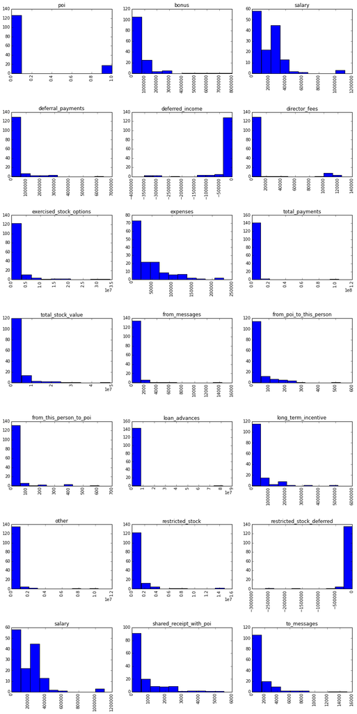

```python
hide_me
%pylab inline

data_to_test = featureFormat(data_dict_updated, features_to_test)
fig = plt.figure(figsize=(15, 30))

for idx, feature in enumerate(features_to_test):
    ax = plt.subplot(7,3, idx+1)
    plt.title(feature)
    plt.xticks(rotation='vertical')
    plt.subplots_adjust(hspace=.6)
    ax.hist(data_to_test[:,idx])
```

## 4. Setting Up Initial Prediction Model

Before continuing with feature selection, let us first focus on getting our prediction model up and running. The reasons are:

1. Getting prediction model to run takes less effort than building new features.
2. When we have our prediction model ready, we can use it to test our new choice of features and see if they improved the model.

### 4.1. What does a prediction model consist of?

A prediction model can contain several steps within it. We call the collection of these steps a "Pipeline". In this project, for example, the pipeline I created have two steps:

1. Scaling of features: This is useful to make sure we have similar scoring throughout our features. In our case, we combined number of messages (values in the thousands) with salary (values in the hundreds of thousands), to ensure, for example, a relatively high number of messages compared to other messages are not valued less than relatively low amount of salary compared to all salaries.
2. Classifier: This step contains the algorithm we use to classify our features into different target class i.e. POI or non POI.

Below is the result of our initial prediction model:

```python
hide_me

random = 13
import copy

my_dataset = copy.deepcopy(data_dict)

from sklearn.tree import DecisionTreeClassifier
from sklearn.pipeline import Pipeline, FeatureUnion
from sklearn.preprocessing import MinMaxScaler

combined_features = FeatureUnion([
        ('scale', MinMaxScaler())
    ])

estimators = [
    ('features', combined_features),
    ('classify', DecisionTreeClassifier(random_state=random))
]

pclf = Pipeline(estimators)

test_classifier(pclf, data_dict_updated, features_to_test)
```

```
Pipeline(steps=[('features', FeatureUnion(n_jobs=1,
       transformer_list=[('scale', MinMaxScaler(copy=True, feature_range=(0, 1)))],
       transformer_weights=None)), ('classify', DecisionTreeClassifier(class_weight=None, criterion='gini', max_depth=None,
            max_features=None, max_leaf_nodes=None, min_samples_leaf=1,
            min_samples_split=2, min_weight_fraction_leaf=0.0,
            random_state=13, splitter='best'))])
	Accuracy: 0.80073	Precision: 0.23599	Recall: 0.22100	F1: 0.22825	F2: 0.22384
	Total predictions: 15000	True positives:  442	False positives: 1431	False negatives: 1558	True negatives: 11569
```

Seeing the above report for the first time might be overwhelming to understand, but it is actually quite simple.

In the first part, the one started with "Pipeline", this report explained the details of our prediction model. That includes all the steps in it and the parameters used in each step. In later step we will try to find the most optimized set of parameters for our model.

The lines below it (started with "Accuracy") report the scores based on our chosen evaluation metrics.

### 4.2. Evaluation Metrics

We can't improve what we can't measure. Similarly in creating a prediction model we need to use a kind of measurement to see if the model is good enough.

The two most important evaluation metrics from that line are "Precision and Recall" and "F1" (that makes it three, but precision and recall are usually stick together).

We do the evaluation by cross-validating our prediction model with given testing dataset using a stratified shuffle split (remember to [check my blog post](http://www.teguhwijaya.com/machine-learning/often-used-machine-learning-terms) if you're lost with the terminology).

In short, better F1 value means better model, and Precision is usually a trade-off against Recall.

## 5. Feature Selection

Digging through the dataset, we found that there seems to be a correlation between being a POI and most of the features, as seen in below correlation matrix.

```python
hide_me
# Export to csv for correlation analysis in R.
df_updated.to_csv('dataset_updated.csv')
```

[figure not shown]

We do not need to manually choose which features to use in our prediction model. They are better selected automatically later using machine learning algorithms.

What we need to find from this correlation model though are features with correlation value to our target, POI, that are close to 0 and see if we can do some feature engineering on them. Correlation between two variables that are close to 0 means changes to them less likely affect each other. The best features for machine learning are features that are highly correlated with targets but not with other features.

### 5.1. To keep or remove aggregated values?

Earlier we found out that `total_salary` and `total_stock_values` are the sum of other features. Is it better to keep these two features, or remove them since they add no new information?

My latest conclusion on this matter is **it depends**. Different type of aggregation have different effects, and the effects are not the same when applied to different algorithms. There are papers explaining various experiments on this but there are simply too many variables and pattern involved. I would say for now the best we can do is to try running it through our test to see if it actually improves or worsen the model (if running the test does not take too much time, that is).

Below is the result when `total_salary` and `total_stock_values` are removed:

```python
hide_me

features_to_test_no_aggregates = [
    'poi',
    'bonus',
    'salary',
    'deferral_payments',
    'deferred_income',
    'director_fees',
    'exercised_stock_options',
    'expenses',
    'from_messages',
    'from_poi_to_this_person',
    'from_this_person_to_poi',
    'loan_advances',
    'long_term_incentive',
    'other',
    'restricted_stock',
    'restricted_stock_deferred',
    'salary',
    'shared_receipt_with_poi',
    'to_messages'
]

combined_features = FeatureUnion([
        ('scale', MinMaxScaler())
    ])

estimators = [
    ('features', combined_features),
    ('classify', DecisionTreeClassifier(random_state=random))
]

pclf = Pipeline(estimators)

test_classifier(pclf, data_dict_updated, features_to_test_no_aggregates)
```

```
Pipeline(steps=[('features', FeatureUnion(n_jobs=1,
       transformer_list=[('scale', MinMaxScaler(copy=True, feature_range=(0, 1)))],
       transformer_weights=None)), ('classify', DecisionTreeClassifier(class_weight=None, criterion='gini', max_depth=None,
            max_features=None, max_leaf_nodes=None, min_samples_leaf=1,
            min_samples_split=2, min_weight_fraction_leaf=0.0,
            random_state=13, splitter='best'))])
	Accuracy: 0.80827	Precision: 0.25881	Recall: 0.23500	F1: 0.24633	F2: 0.23941
	Total predictions: 15000	True positives:  470	False positives: 1346	False negatives: 1530	True negatives: 11654
```

### 5.2. Will imputing be useful in our dataset?

Imputing is the process of replacing missing values with either 'mean', 'median', or 'most_frequent' values, in hope that they will be more statistically insignificant rather than replacing missing values with 0.

However, we do not need this in our dataset since NaN values in our dataset are really 0. This was proven from the raw data that when these values, including 0 values totalled they accumulated into `total_payments` and `total_stock_value`.

```python
### Convert all NaN values to 0.
hide_me

data_dict_zero = copy.deepcopy(data_dict_updated)

for name, item in data_dict_zero.items():
    for key in features_to_test:
        if item[key] == 'NaN':
            data_dict_zero[name][key] = 0
```

## 6. Feature Engineering

Let's try to create new feature(s) and see if that improves our precision and recall store.

### 6.1. Creating email ratio features

There are two new features that could be potentially useful:

1. `from_this_person_to_poi_ratio`: Messages sent from this person to pois compared to all messages sent by this person.
2. `from_poi_to_this_person_ratio`: Messages received by this person from pois compared to all messages received by this person.

```python
### Create and display the new features we just created
hide_me

# fe stands for Feature Engineered, in case you wondered...
data_dict_fe = data_dict_zero

for name, item in data_dict_fe.items():
    data_dict_fe[name]['from_this_person_to_poi_ratio'] = 0
    data_dict_fe[name]['from_poi_to_this_person_ratio'] = 0
    if item['from_messages'] > 0:
        data_dict_fe[name]['from_this_person_to_poi_ratio'] = float(item['from_this_person_to_poi']) / float(item['from_messages'])
    if item['to_messages'] > 0:
        data_dict_fe[name]['from_poi_to_this_person_ratio'] = float(item['from_poi_to_this_person']) / float(item['to_messages'])

df_fe = to_pandas(data_dict_fe)
print "From This Person to POI Ratio"
print df_fe['from_this_person_to_poi_ratio'].describe()
print df_fe.ix[:,['poi', 'from_this_person_to_poi_ratio', 'from_this_person_to_poi', 'from_messages']].head(5)

print "\n"
print "From POI to This Person Ratio"
print df_fe['from_poi_to_this_person_ratio'].describe()
print df_fe.ix[:,['poi', 'from_poi_to_this_person_ratio', 'from_poi_to_this_person', 'to_messages']].head(5)
```

```
From This Person to POI Ratio
count    145.000000
mean     0.109164
std      0.185513
min      0.000000
25%      0.000000
50%      0.000000
75%      0.198436
max      1.000000
Name: from_this_person_to_poi_ratio, dtype: float64
   poi  from_this_person_to_poi_ratio  from_this_person_to_poi  from_messages
0  0    0.029613                       65                       2195
1  0    0.000000                       0                        0
2  0    0.000000                       0                        29
3  0    0.000000                       0                        0
4  0    0.000000                       0                        0


From POI to This Person Ratio
count    145.000000
mean     0.022516
std      0.036339
min      0.000000
25%      0.000000
50%      0.004885
75%      0.029817
max      0.217341
Name: from_poi_to_this_person_ratio, dtype: float64
   poi  from_poi_to_this_person_ratio  from_poi_to_this_person  to_messages
0  0    0.016196                       47                       2902
1  0    0.000000                       0                        0
2  0    0.068905                       39                       566
3  0    0.000000                       0                        0
4  0    0.000000                       0                        0
```

Let's use them in our prediction model in place of their substances (`from_this_person_to_poi`, `from_messages`, etc.).

```python
features_list_fe = [
    'poi',
    'bonus',
    'salary',
    'deferral_payments',
    'deferred_income',
    'director_fees',
    'exercised_stock_options',
    'expenses',
    'from_poi_to_this_person_ratio',
    'from_this_person_to_poi_ratio',
    'loan_advances',
    'long_term_incentive',
    'other',
    'restricted_stock',
    'restricted_stock_deferred',
    'salary',
    'shared_receipt_with_poi'
]

combined_features_fe = FeatureUnion([
        ('scale', MinMaxScaler())
    ])

estimators_fe = [
    ('features', combined_features_fe),
    ('classify', DecisionTreeClassifier(random_state=random))
]

# Rebuilding the classifier
pclf_fe = Pipeline(estimators_fe)

test_classifier(pclf_fe, data_dict_fe, features_list_fe)
```

```
Pipeline(steps=[('features', FeatureUnion(n_jobs=1,
       transformer_list=[('scale', MinMaxScaler(copy=True, feature_range=(0, 1)))],
       transformer_weights=None)), ('classify', DecisionTreeClassifier(class_weight=None, criterion='gini', max_depth=None,
            max_features=None, max_leaf_nodes=None, min_samples_leaf=1,
            min_samples_split=2, min_weight_fraction_leaf=0.0,
            random_state=13, splitter='best'))])
	Accuracy: 0.82433	Precision: 0.33316	Recall: 0.31700	F1: 0.32488	F2: 0.32011
	Total predictions: 15000	True positives:  634	False positives: 1269	False negatives: 1366	True negatives: 11731
```

Alright, seems like it does improve our prediction model even further.

### 6.2. Importance rank of all features

Below is a list of feature ranks, ordered by best to worst.

```python
hide_me
importances = pclf_fe.steps[-1][1].feature_importances_
indices = np.argsort(importances)[::-1]

# Print the feature ranking
print("Feature ranking:")
print indices

for f in range(16):
    # [1:] is important since the first item is "poi"!
    print("%d. %s (%0.2f)" % (f + 1, features_list_fe[1:][indices[f]], importances[indices[f]]))
```

```
Feature ranking:
[ 5  8 15 10  7 11 12  0 14 13  9  6  4  3  2  1]
1. exercised_stock_options (0.40)
2. from_this_person_to_poi_ratio (0.13)
3. shared_receipt_with_poi (0.13)
4. long_term_incentive (0.12)
5. from_poi_to_this_person_ratio (0.11)
6. other (0.07)
7. restricted_stock (0.03)
8. bonus (0.01)
9. salary (0.00)
10. restricted_stock_deferred (0.00)
11. loan_advances (0.00)
12. expenses (0.00)
13. director_fees (0.00)
14. deferred_income (0.00)
15. deferral_payments (0.00)
16. salary (0.00)
```

Looks like the newly created ratio features ranked quite high in their importance.

### 6.3. Is NOT including the substances of our new features better for the model?

Out of curiosity, let's try including all the substances into our list of features and see if that improves or degrades our model. Below is the result of an exactly similar code as above, but with `from_poi_to_this_person`, `from_this_person_to_poi`, `to_messages`, `from_messages` included in our features:

```python
hide_me
features_list_fe2 = [
    'poi',
    'bonus',
    'salary',
    'deferral_payments',
    'deferred_income',
    'director_fees',
    'exercised_stock_options',
    'expenses',
    'from_poi_to_this_person_ratio',
    'from_this_person_to_poi_ratio',
    'from_poi_to_this_person',
    'from_this_person_to_poi',
    'from_messages',
    'to_messages',
    'loan_advances',
    'long_term_incentive',
    'other',
    'restricted_stock',
    'restricted_stock_deferred',
    'salary',
    'shared_receipt_with_poi'
]

combined_features_fe2 = FeatureUnion([
        ('scale', MinMaxScaler())
    ])

estimators_fe2 = [
    ('features', combined_features_fe2),
    ('classify', DecisionTreeClassifier(random_state=random))
]

# Rebuilding the classifier
pclf_fe2 = Pipeline(estimators_fe2)

test_classifier(pclf_fe2, data_dict_fe, features_list_fe2)
```

```
Pipeline(steps=[('features', FeatureUnion(n_jobs=1,
       transformer_list=[('scale', MinMaxScaler(copy=True, feature_range=(0, 1)))],
       transformer_weights=None)), ('classify', DecisionTreeClassifier(class_weight=None, criterion='gini', max_depth=None,
            max_features=None, max_leaf_nodes=None, min_samples_leaf=1,
            min_samples_split=2, min_weight_fraction_leaf=0.0,
            random_state=13, splitter='best'))])
	Accuracy: 0.81827	Precision: 0.30547	Recall: 0.28500	F1: 0.29488	F2: 0.28887
	Total predictions: 15000	True positives:  570	False positives: 1296	False negatives: 1430	True negatives: 11704
```

```python
hide_me
importances = pclf_fe2.steps[-1][1].feature_importances_
indices = np.argsort(importances)[::-1]

# Print the feature ranking
print("Feature ranking:")
print indices

for f in range(20):
    # [1:] is important since the first item is "poi"!
    print("%d. %s (%0.2f)" % (f + 1, features_list_fe2[1:][indices[f]], importances[indices[f]]))
```

```
Feature ranking:
[ 5 19  8 14 16  9 13 12 11 10 18 15  7  6 17  4  3  2  1  0]
1. exercised_stock_options (0.40)
2. shared_receipt_with_poi (0.19)
3. from_this_person_to_poi_ratio (0.13)
4. long_term_incentive (0.12)
5. restricted_stock (0.09)
6. from_poi_to_this_person (0.07)
7. loan_advances (0.00)
8. to_messages (0.00)
9. from_messages (0.00)
10. from_this_person_to_poi (0.00)
11. salary (0.00)
12. other (0.00)
13. from_poi_to_this_person_ratio (0.00)
14. expenses (0.00)
15. restricted_stock_deferred (0.00)
16. director_fees (0.00)
17. deferred_income (0.00)
18. deferral_payments (0.00)
19. salary (0.00)
20. bonus (0.00)
```

Yep, seems like, contrary to what we previously analyzed when working with `total_salaries` and `total_stock_value` where it was better to remove the aggregates but keep the substances, in this case it is better to remove the substances but keep the aggregates.

## 7. Text Learning From Emails

Emails sent and received by Enron's employees are publicly available for [download](https://www.cs.cmu.edu/~./enron/). In this section I attempt to load the dataset and see if we can improve the prediction with them added into our features.

To do this, first I loaded all emails from their respective directories, then vectorize and combine them with our previous features, then classify them.

I used sklearn's implementation of Tfidf algorithm to vectorize the messages using the module TfidfVectorizer.

### 7.1. Initial Tfidf Implementation

Prior to implementing TfidfVectorizer in our dataset, I wanted to find a proof if it was going to be useful. I created a small script to test classfying only vectorized words in "Bag of Words Implementation" document. The quality metrics given at the end was as follows:

```
DecisionTreeClassifier(class_weight=None, criterion='gini', max_depth=None,
            max_features=None, max_leaf_nodes=None, min_samples_leaf=1,
            min_samples_split=2, min_weight_fraction_leaf=0.0,
            random_state=13, splitter='best')
    Accuracy: 0.85665    Precision: 0.65509    Recall: 0.25822    F1: 0.37042    F2: 0.29382
```

```python
%%time
hide_me
import os
import sys
sys.path.append("../tools/")
from parse_out_email_text import parseOutText

### Warning! running this script will take a really long time, not to mention that you will need a copy of
### Enron's email addresses from Udacity's Into to Machine Learning course.
### Download this file instead (400+Mb) https://www.dropbox.com/s/6o79pqvxrp0xylv/enron_emails_all_words.pkl?dl=0
### Otherwise you can safely skip the scripts in this section and move on to next one.

# Change this to where you want all words pickle document to be kept.
all_words_path = 'D:\\Projects\\data_science\\nanodegree_data_analyst\\intro_to_ml\\enron_emails_all_words.pkl'



word_data = []
key_data = []
email_types = []
poi_data = []
# temp_counter = 0

if (os.path.isfile(all_words_path)):
    all_words = cPickle.load(open(all_words_path, "r"))
    word_data, key_data, email_types, poi_data = zip(*all_words)
else:
    dirpath = 'emails_by_address/'
    filenames = next(os.walk(dirpath))[2]
    for key, value in data_dict_fe.items():
        if value['email_address'] != 0:
            paths = [
                dirpath + 'from_' + value['email_address'] + '.txt',
                dirpath + 'to_' + value['email_address'] + '.txt',
            ]
            for idx, path in enumerate(paths):
                if os.path.isfile(path):
                    print "reading", path, '...'
                    email_list = open(path, 'r')
                    for email_path in email_list:
                        ### only look at first 100 emails when developing
                        ### once everything is working, remove this line to run over full dataset
                        # temp_counter += 1
                        # if temp_counter < 100:
                        email_path = '..' + email_path[19:-2]
                        if os.path.isfile(email_path):
                            email = open(email_path, 'r')
                            text = parseOutText(email)
                            word_data.append(text)
                            key_data.append(key)
                            poi_data.append(data_dict_fe[key]['poi'])
                            if idx == 0:
                                email_types.append('from')
                            else:
                                email_types.append('to')
    all_words = zip(word_data, key_data, email_types, poi_data)
    cPickle.dump(all_words, open(all_words_path, "w") )
```

```
Wall time: 1min 1s
```

### 7.2. Pipeline of our predictor

I created a Pipeline with custom TfidfVectorizer and MinMaxScaler classes where they would be compatible to our data model. This way we can use it with our tester.

These are step-by-step processes of this Pipeline:

1. Combine the messages for each person i.e. one person one document, then tfidf the messages.
2. MinMax scale non-message features as we did previously.
3. Combine the features resulted from both of above steps.
4. Some people in our dataset do not have any message associated with them, resulting in NaN values in some message related features. We need to run the features through an Imputer to convert these NaN values into statistically insignificant values.
5. Reduce features dimensionality through PCA algorithm to help them generalize better, since with this we end up with 100 additional features from the words alone.
6. And finally classify the dataset through DecisionTreeClassifier.

```python
hide_me

from sklearn.base import BaseEstimator, TransformerMixin
from sklearn.feature_extraction.text import TfidfVectorizer
from sklearn.decomposition import PCA

### FeatureCombiner. Used to combine the features returned from transformers in FeatureUnion.

class FeaturesCombiner(BaseEstimator, TransformerMixin):
    def fit(self, x, y=None):
        return self

    def transform(self, x):
        ### SAMPLE CODE 1:
        ### Enable the following sample code to find out FeatureUnion's behavior.
#         print "len x: ", len(x[0])
#         print "x16: ", x[0][16]
#         print "x34: ", x[0][34]
#         print "x52: ", x[0][52]

        new_x = range(len(x))
        for idx, value in enumerate(x):
            # Get 1/3 of features
            new_values = value[:(len(value)/3)]
            idx_to_delete_list = []
            for f_idx, feature in enumerate(new_values):
                # Flatten any dict found in x
                if isinstance(feature, (dict)):
                    new_values = numpy.concatenate((new_values, feature.values()), axis=0)
                    idx_to_delete_list.append(f_idx)
            new_values = np.delete(new_values, idx_to_delete_list, 0)
            new_x[idx] = new_values
        return new_x

### Custom TfidfVectorizer. Instead of accepting only list of documents,
### I made it compatible with data_dict from our project.

class MyTfidfVectorizer(TfidfVectorizer):
    def __init__(self, input='content', encoding='utf-8',
                 decode_error='strict', strip_accents=None, lowercase=True,
                 preprocessor=None, tokenizer=None, analyzer='word',
                 stop_words=None, token_pattern=r"(?u)\b\w\w+\b",
                 ngram_range=(1, 1), max_df=1.0, min_df=1,
                 max_features=None, vocabulary=None, binary=False,
                 dtype=np.int64, norm='l2', use_idf=True, smooth_idf=True,
                 sublinear_tf=False, feature_id=None, feature_prefix='to_'):
        self.feature_id = feature_id
        self.feature_prefix = feature_prefix
        super(MyTfidfVectorizer, self).__init__(
            input=input, encoding=encoding, decode_error=decode_error,
            strip_accents=strip_accents, lowercase=lowercase,
            preprocessor=preprocessor, tokenizer=tokenizer, analyzer=analyzer,
            stop_words=stop_words, token_pattern=token_pattern,
            ngram_range=ngram_range, max_df=max_df, min_df=min_df,
            max_features=max_features, vocabulary=vocabulary, binary=binary,
            dtype=dtype)

    def fit(self, x, y=None):
        documents, document_keys = self.get_documents_from_data_dict(x)
        # Sometimes we ends up with data woth no documents, and that is alright
        if len(documents) != 0:
            super(MyTfidfVectorizer, self).fit(documents, y=y)
        return self

    def transform(self, x):
        documents, document_keys = self.get_documents_from_data_dict(x)
        # Sometimes we ends up with data woth no documents, and that is alright
        if len(documents) == 0:
            transformed_docs = []
        else:
            transformed_docs = super(MyTfidfVectorizer, self).transform(documents)
        x = self.attach_results_into_data_dict(x, transformed_docs, document_keys)
        return x

    def fit_transform(self, x, y=None):
        documents, document_keys = self.get_documents_from_data_dict(x)
        # Sometimes we ends up with data woth no documents, and that is alright
        if len(documents) == 0:
            transformed_docs = []
        else:
            transformed_docs = super(MyTfidfVectorizer, self).fit_transform(documents, y=y)
        x = self.attach_results_into_data_dict(x, transformed_docs, document_keys)
        return x

    # Getting only the text documents from given dictionary.
    def get_documents_from_data_dict(self, data_dict):
        documents = []
        document_keys = []
        for idx, value in enumerate(data_dict):
            if len(value[self.feature_id]) > 0:
                documents.append(' '.join(value[self.feature_id]))
                document_keys.extend([idx])
        # In here we will end up with:
        # - documents: a list of all email messages of everyone.
        # - document_keys: a list of ids each document belong to

        ### SAMPLE CODE 2:
        ### Small sample set for development:
#         if self.feature_id == 17:
#             documents = ['this is text number 1', 'what a good day this is']
#         else:
#             documents = ['this is text number 2', 'what a bad day this is']
#         document_keys = [0, 1]

        return (documents, document_keys)

    # Reattach transformed texts back into list of features.
    def attach_results_into_data_dict(self, x, transformed_docs, document_keys):
        for idx, value in enumerate(x):
            scores = dict()
            for f_idx, feature_name in enumerate(self.get_feature_names()):
                if idx in document_keys:
                    document_key = document_keys.index(idx)
                    scores[self.feature_prefix + feature_name] = transformed_docs[document_key, f_idx]
                else:
                    scores[self.feature_prefix + feature_name] = None
            # We want to replace feature number `self.feature_id` in x with
            # [list of scores], to later be combined with FeaturesCombiner.
            x[idx][self.feature_id] = scores
        return x

### MinMaxScaler made compatible with our data_dict structure.

class MyMinMaxScaler(MinMaxScaler):
    # feature_ids: Feature ids to apply scaling at. None means all.
    def __init__(self, feature_range=(0, 1), copy=True, feature_ids=None):
        super(MyMinMaxScaler, self).__init__(feature_range=feature_range, copy=copy)
        self.feature_ids = feature_ids

    def fit(self, x, y=None):
        x_selected = self.select_x(x)
        return super(MyMinMaxScaler, self).fit(x_selected, y)

    def transform(self, X):
        x_selected = self.select_x(X)
        x_transformed = super(MyMinMaxScaler, self).transform(x_selected)
        X_updated = range(len(X))
        for idx, original_features in enumerate(X):
            X_updated[idx] = x_transformed[idx]
            ### SAMPLE CODE 3:
            ### Enable these to understand how transformation and concatenation works.
#             print "before concat: ", shape(X_updated[idx])
#             print "len of x: ", len(X[idx])
#             print "len of x_transformed: ", len(x_transformed[idx])
#             print "concat with: ", X[idx][len(x_transformed[idx]):]
            X_updated[idx] = numpy.concatenate((X_updated[idx], X[idx][len(x_transformed[idx]):]),
                                               axis=0)
#             print "after concat: ", shape(X_updated[idx])
        return X_updated

    # Select part of features to scale.
    def select_x(self, x):
        x_selected = []
        for item in x:
            item_sel = []
            for idx in self.feature_ids:
                item_sel.append(item[idx])
            x_selected.append(item_sel)
        return x_selected
```

```python
### Insert word data into our latest dataset
hide_me

data_dict_with_words = copy.deepcopy(data_dict_fe)

email_messages = []
for idx, message in enumerate(word_data):
    key = key_data[idx]
    if email_types[idx] == 'from':
        if 'from_messages_texts' not in data_dict_with_words[key].keys():
            data_dict_with_words[key]['from_messages_texts'] = []
        data_dict_with_words[key]['from_messages_texts'].append(message)
    elif email_types[idx] == 'to':
        if 'to_messages_texts' not in data_dict_with_words[key].keys():
            data_dict_with_words[key]['to_messages_texts'] = []
        data_dict_with_words[key]['to_messages_texts'].append(message)

# For people without email messages:
for key, value in data_dict_with_words.items():
    if 'from_messages_texts' not in value.keys():
        data_dict_with_words[key]['from_messages_texts'] = []
    if 'to_messages_texts' not in value.keys():
        data_dict_with_words[key]['to_messages_texts'] = []

features_list_with_words = copy.deepcopy(features_list_fe)
features_list_with_words.append('to_messages_texts')
features_list_with_words.append('from_messages_texts')
```

```python
hide_me

from sklearn.preprocessing import Imputer

pipeline = Pipeline([
    ('union', FeatureUnion(
        transformer_list=[
            # Pipeline for standard bag-of-words model for "to" emails
            ('email_to_bow', Pipeline([
                ('tfidf', MyTfidfVectorizer(feature_prefix='to_', feature_id=features_list_with_words.index('to_messages_texts')-1,
                                            sublinear_tf=True,
                                            max_features=100, stop_words='english'))
            ])),

            # Pipeline for standard bag-of-words model for "from" emails
            ('email_from_bow', Pipeline([
                ('tfidf', MyTfidfVectorizer(feature_prefix='from_', feature_id=features_list_with_words.index('from_messages_texts')-1,
                                            sublinear_tf=True,
                                            max_features=100, stop_words='english'))
            ])),

            # Pipeline to scale non email message related features (salary, bonus, etc.)
            ('min_max_scaler', MyMinMaxScaler(feature_ids=range(0, len(features_list_with_words)-3)))
        ]
    )),

    # At this point, our data that will be passed to features combiner contains items with, rather mysteriously,
    # following features:
    # [
    #   (min_max scaled non-email features), {(dict of to messages scores)}, {(dict of from messages scores )}
    #   (min_max scaled non-email features), {(dict of to messages scores)}, {(dict of from messages scores )}
    #   (min_max scaled non-email features), {(dict of to messages scores)}, {(dict of from messages scores )}
    # ]
    #
    # rather than (notice the commas as well as scores / texts):
    #
    # [
    #   (unscaled non-email features), {(dict of to messages scores)}, [(list of from messages texts)],
    #   (unscaled non-email features), {(dict of to messages scores)}, {(dict of from messages scores)},
    #   (min_max scaled non-email features), {(dict of to messages scores)}, {(dict of from messages scores)}
    # ]
    #
    # Perhaps it is something about the behaviors of FeatureUnion that we later need to investigate further.
    # Uncomment SAMPLE CODE comments above to start investigation.
    #
    # In our features_combiner step below, we want to do two things:
    # 1. Get 1/3 of our features.
    # 2. Flatten our features into:
    #    [(min_max scaled features), (to messages scores), (from messages scores)]
    #    and later use them in our classifier step.
    ('features_combiner', FeaturesCombiner()),
    ("imputer", Imputer(axis=0, missing_values="NaN")),
    ('dim_reduce', PCA(n_components=20)),
    ('classifier', DecisionTreeClassifier(random_state=random)),
])
```

```python
%%time
hide_me
### Used in development of feature_format to reimport that file.
# import feature_format
# feature_format = reload(sys.modules['feature_format'])
# featureFormat = feature_format.featureFormat

from sklearn import cross_validation

# test if the function works by using few data.
def test_pipeline(clf, data_dict, features_list, random):
    # I had to update the function featureFormat to accept list in their values.
    data = featureFormat(data_dict, features_list, sort_keys = True, to_np_array = False)
    labels, features = targetFeatureSplit(data)
    f_train, f_test, l_train, l_test = cross_validation.train_test_split(features, labels, test_size=0.95, random_state=random)
    predictions = clf.fit(f_train, l_train)
    l = clf.predict(f_train)

import tester
tester = reload(sys.modules['tester'])
test_classifier = tester.test_classifier

### Enable this line to test with smaller data
# test_pipeline(pipeline, data_dict_with_words, features_list_with_words, random)
test_classifier(pipeline, data_dict_with_words, features_list_with_words, folds=10, to_np_array = False)
```

```
Pipeline(steps=[('union', FeatureUnion(n_jobs=1,
       transformer_list=[('email_to_bow', Pipeline(steps=[('tfidf', MyTfidfVectorizer(analyzer='word', binary=False, decode_error='strict',
         dtype=<type 'numpy.int64'>, encoding='utf-8', feature_id=16,
         feature_prefix='to_', input='content', lo...  min_samples_split=2, min_weight_fraction_leaf=0.0,
            random_state=13, splitter='best'))])
	Accuracy: 0.80000	Precision: 0.22222	Recall: 0.20000	F1: 0.21053	F2: 0.20408
	Total predictions:  150	True positives:    4	False positives:   14	False negatives:   16	True negatives:  116

Wall time: 1min 39s
```

The scores were surprisingly low!

The consequence of combining the messages was that it left us a much less documents to work with i.e. whereas before we have tens of thousands of emails, now we only have 111 data points to work with. Perhaps that was the main reason why we get really low precision and recall values.

In addition to that, the runtime for vectorization is painfully slower than using our initial prediction model. Running 100 folds took about 3.5 minutes, and doubling that to 200 folds took 6 minutes 41 seconds, make it 500 and it took a whopping 18.6 minutes. I dare not go further. As comparison, so far we have been running 1000 folds in about 30 seconds.

With 100 folds our F1 score was 0.28, with 200 folds it was 0.30, and 500 folds at 0.28.

On the other hand, using merely email messages as shown in "Bag of Words Implementation" document gave us much higher F1 scores (about 0.37). However, since we cannot use our tester function to test it, we shall move forward with our best classifier so far in this document.

## 8. Pick An Algorithm

Now that we have optimized our features, It is time to do the final step, to pick a classifier algorithm and later to tune it.

### 8.1. Is our algorithm better than random guesses?

I tend to think that, whichever algorithm we will end up with, that algorithm MUST show better performance than random guesses, otherwise why would we even use Machine Learning, right?

This was the reason too in using Stratified Shuffle Split in our validation, which basically splitting and shuffling our training and testing dataset a few times, predict and score these sets, and calculate our total scores (accuracy, precision, recall, f1, and f2 scores). The default is running 1000 folds, meaning 1000 different splits and shuffles of training and testing data.

```python
hide_me
from sklearn.dummy import DummyClassifier

clf = DummyClassifier(random_state=random)

test_classifier(clf, data_dict_fe, features_list_fe)
```

```
DummyClassifier(constant=None, random_state=13, strategy='stratified')
	Accuracy: 0.76933	Precision: 0.13500	Recall: 0.13500	F1: 0.13500	F2: 0.13500
	Total predictions: 15000	True positives:  270	False positives: 1730	False negatives: 1730	True negatives: 11270
```

### 8.2. Spot Checking

Spot checking is basically a systematic way to test out different algorithms quickly. For this project, I am going to try only a handful of algorithms but with all the best practices as recommended by [this article](http://machinelearningmastery.com/why-you-should-be-spot-checking-algorithms-on-your-machine-learning-problems/).

#### Algorithms

- DecisionTreeClassifier (from tree category)
- SVC (from kernel category)
- GaussianNB / Gaussian Naive Bayes (from bayesian category to work with continuous data)

On the next step (section "Tune The Algorithm" below) we will run AdaBoostClassifier with the best of above three algorithms.

#### Use basic tuning

On each algorithm, I will tune only a few configuration for spot checking.

#### Digging Deeper

Once an algorithm out of a distinct category has proven to be better (in terms of F1-score and computational cost), we will try different algorithms within that category, with similar rules for tuning.

```python
hide_me
### Testing algorithms from four different categories.
from sklearn.tree import DecisionTreeClassifier
from sklearn.svm import SVC
from sklearn.naive_bayes import GaussianNB
from sklearn.ensemble import AdaBoostClassifier

from sklearn.metrics import f1_score
from sklearn.grid_search import GridSearchCV

combined_features = FeatureUnion([
        ('scale', MinMaxScaler())
    ])

from sklearn.cross_validation import StratifiedShuffleSplit
data_fe = featureFormat(data_dict_fe, features_list_fe, sort_keys = True)
labels, feature_values = targetFeatureSplit(data_fe)
folds = 1000
cv = StratifiedShuffleSplit(
     labels, folds, random_state=random)

# from sklearn.cross_validation import train_test_split
# feature_values, feature_values_test, labels, labels_test = train_test_split(
#     feature_values, labels, test_size=0, random_state=random)
# cv = None
```

Result of running with DecisionTreeClassifier algorithm:

```python
hide_me

decision_tree_estimators = [
    ('features', combined_features),
    ('classifier', DecisionTreeClassifier(random_state=random))
]

# Parameters used in GridSearchCV
decision_tree_parameters = [
    {
        'classifier__max_features': [None, 'auto', 'log2'],
        'classifier__criterion': ['gini', 'entropy']
    }
]

decision_tree_clf = Pipeline(decision_tree_estimators)

# use verbose=n in GridSearchCV parameters to periodically update the output with results.
# Very useful to relieve anxiety when running the algorithm.
decision_tree_grid = GridSearchCV(decision_tree_clf, decision_tree_parameters, cv = cv, scoring='f1')
decision_tree_grid.fit(feature_values, labels)

print("The best parameters are %s with a score of %0.2f"
      % (decision_tree_grid.best_params_, decision_tree_grid.best_score_))
```

```
The best parameters are {'classifier__max_features': 'auto', 'classifier__criterion': 'entropy'} with a score of 0.36
```

```python
%%time
hide_me
### Then we test it with our tester code
decision_tree_clf_fin = decision_tree_clf.set_params(**decision_tree_grid.best_params_)
test_classifier(decision_tree_clf_fin, data_dict_fe, features_list_fe)
```

```
Pipeline(steps=[('features', FeatureUnion(n_jobs=1,
       transformer_list=[('scale', MinMaxScaler(copy=True, feature_range=(0, 1)))],
       transformer_weights=None)), ('classifier', DecisionTreeClassifier(class_weight=None, criterion='entropy', max_depth=None,
            max_features='auto', max_leaf_nodes=None, min_samples_leaf=1,
            min_samples_split=2, min_weight_fraction_leaf=0.0,
            random_state=13, splitter='best'))])
	Accuracy: 0.84380	Precision: 0.40902	Recall: 0.38550	F1: 0.39691	F2: 0.38998
	Total predictions: 15000	True positives:  771	False positives: 1114	False negatives: 1229	True negatives: 11886

Wall time: 1.07 s
```

```python
hide_me

svm_estimators = [
    ('features', combined_features),
    ('classifier', SVC(random_state=random))
]

svm_parameters = [
    {
        # http://scikit-learn.org/stable/modules/svm.html#tips-on-practical-use
        # Lower C corresponds to more regularized estimation i.e. better for noisy data
         'classifier__class_weight': [{1: 1, 0: 0.5}, {1: 0.8, 0: 0.3}, {1:1, 0:1}],
    }
]

svm_clf = Pipeline(svm_estimators)

svm_grid = GridSearchCV(svm_clf, svm_parameters, cv = cv, scoring='f1')
int_labels = [int(i) for i in labels]
svm_grid.fit(feature_values, int_labels)

print("The best parameters are %s with a score of %0.2f"
      % (svm_grid.best_params_, svm_grid.best_score_))
```

```
The best parameters are {'classifier__class_weight': {0: 0.5, 1: 1}} with a score of 0.00
```

```python
%%time
hide_me
### Then we test it with our tester code

svm_clf_fin = svm_clf.set_params(**svm_grid.best_params_)
test_classifier(svm_clf_fin, data_dict_fe, features_list_fe)
```

```
Pipeline(steps=[('features', FeatureUnion(n_jobs=1,
       transformer_list=[('scale', MinMaxScaler(copy=True, feature_range=(0, 1)))],
       transformer_weights=None)), ('classifier', SVC(C=1.0, cache_size=200, class_weight={0: 0.5, 1: 1}, coef0=0.0, degree=3,
  gamma=0.0, kernel='rbf', max_iter=-1, probability=False, random_state=13,
  shrinking=True, tol=0.001, verbose=False))])
	Accuracy: 0.86667	Precision: 0.00000	Recall: 0.00000	F1: 0.00000	F2: 0.00000
	Total predictions: 15000	True positives:    0	False positives:    0	False negatives: 2000	True negatives: 13000

Wall time: 1.41 s
```

Seems like for some reason Support Vector Machine Classifier is not usable in our problem set.

Below is the result for GaussianNB:

```python
hide_me

nb_estimators = [
    ('features', combined_features),
    ('classifier', GaussianNB())
]

nb_parameters = [
    {
        # GaussianNB has no configurations to set.
    }
]

nb_clf = Pipeline(nb_estimators)

nb_grid = GridSearchCV(nb_clf, nb_parameters, cv = cv, scoring='f1')
nb_grid.fit(feature_values, labels)

print("The best parameters are %s with a score of %0.2f"
      % (nb_grid.best_params_, nb_grid.best_score_))
```

```
The best parameters are {} with a score of 0.29
```

```python
%%time
hide_me
### Then we test it with our tester code
nb_clf_fin = nb_clf.set_params(**nb_grid.best_params_)
test_classifier(nb_clf_fin, data_dict_fe, features_list_fe)
```

```
Pipeline(steps=[('features', FeatureUnion(n_jobs=1,
       transformer_list=[('scale', MinMaxScaler(copy=True, feature_range=(0, 1)))],
       transformer_weights=None)), ('classifier', GaussianNB())])
	Accuracy: 0.40287	Precision: 0.16722	Recall: 0.87400	F1: 0.28074	F2: 0.47364
	Total predictions: 15000	True positives: 1748	False positives: 8705	False negatives:  252	True negatives: 4295

Wall time: 1.28 s
```

### 8.3. Spot Checking Pole Position

Here is the summary of spot checking we did above:

```
                        time (sec)   |   precision   |   recall   |   F1-score
DecisionTreeClassifier  1.27             0.40902         0.38550      0.39691
SVC                     1.42             0.0             0.0          0.0
GaussianNB              1.3              0.16722         0.87400      0.28074
```

Looks like, all things being equal, DecisionTreeClassifier seems to be superior in our problem set. SVC on the other hand seems to have a problem predicting our dataset.

### 8.4. AdaBoost

Often referred as "the best out of the box", AdaBoost improves the output of other weak learners by combining them into a weighted sum that represents the final output of the boosted classifier. When used with decision tree learning, information gathered at each stage of the AdaBoost algorithm about the relative 'hardness' of each training sample is fed into the tree growing algorithm such that later trees tend to focus on harder to classify examples. (excerpt from [Wikipedia](https://en.wikipedia.org/wiki/AdaBoost))

Let's see whether AdaBoost would improve our model before we move further with tuning classifiers' configurations.

```python
hide_me
### Setting AdaBoostClassifier with best parameters as found above
ada_boost_estimators = [
    ('features', combined_features),
    ('classifier', AdaBoostClassifier(random_state=random))
]

# Best parameters used in our DecisionTreeClassifier.
best_params = decision_tree_clf_fin.steps[-1][1].get_params()

ada_boost_parameters = [
    {
        # Trying out AdaBoost with different weak classifiers.
        'classifier__base_estimator': [DecisionTreeClassifier(**best_params)],
        'classifier__n_estimators': [10, 50, 70],
        'classifier__learning_rate': [0.1, 0.3, 0.7, 1]
    }
]

ada_boost_clf = Pipeline(ada_boost_estimators)

ada_boost_grid = GridSearchCV(ada_boost_clf, ada_boost_parameters, cv = cv, scoring='f1')
ada_boost_grid.fit(feature_values, labels)

print("The best parameters are %s with a score of %0.2f"
      % (ada_boost_grid.best_params_, ada_boost_grid.best_score_))
```

```
The best parameters are {'classifier__learning_rate': 0.1, 'classifier__base_estimator': DecisionTreeClassifier(class_weight=None, criterion='entropy', max_depth=None,
            max_features='auto', max_leaf_nodes=None, min_samples_leaf=1,
            min_samples_split=2, min_weight_fraction_leaf=0.0,
            random_state=13, splitter='best'), 'classifier__n_estimators': 10} with a score of 0.35
```

```python
%%time
hide_me
### Then we test it with our tester code
ada_boost_clf_fin = ada_boost_clf.set_params(**ada_boost_grid.best_params_)
test_classifier(ada_boost_clf_fin, data_dict_fe, features_list_fe)
```

```
Pipeline(steps=[('features', FeatureUnion(n_jobs=1,
       transformer_list=[('scale', MinMaxScaler(copy=True, feature_range=(0, 1)))],
       transformer_weights=None)), ('classifier', AdaBoostClassifier(algorithm='SAMME.R',
          base_estimator=DecisionTreeClassifier(class_weight=None, criterion='entro... random_state=13, splitter='best'),
          learning_rate=0.1, n_estimators=10, random_state=13))])
	Accuracy: 0.84387	Precision: 0.41000	Recall: 0.38950	F1: 0.39949	F2: 0.39343
	Total predictions: 15000	True positives:  779	False positives: 1121	False negatives: 1221	True negatives: 11879

Wall time: 1.8 s
```

AdaBoost classifier does seem to improve our model. Later we shall use AdaBoost to improve the most optimized version of our classifier.

```
                        time (sec)   |   precision   |   recall   |   F1-score
DecisionTreeClassifier  1.27             0.40902         0.38550      0.39691
AdaBoostClassifier      1.8              0.41000         0.38950      0.39949
```

### 8.5. Digging Deeper: Trying out other algorithms within the winning category

We can now be quite sure that tree estimators are better fitted to our problem set. There are a couple other algorithms in this category we can try out:

- Iterative Dichotomiser 3 / ID3 (not implemented in sklearn)
- C4.5 and C5.0 (DecisionTreeClassifier uses something similar to C4.5 called CART, C5.0 is not implemented in sklearn)
- Chi-squared Automatic Interaction Detection / CHAID (not implemented in sklearn)
- Decision Stump / this is just an alias of algorithms used in AdaBoost
- Random Forest (RandomForestClassifier)
- Multivariate Adaptive Regression Splines /MARS ([available outside of sklearn](https://github.com/jcrudy/py-earth) so let's not use it for now)
- Gradient Boosting Machines / GBM (GradientBoostingClassifier)

([This is the great article that covered this topic by the way](http://machinelearningmastery.com/a-tour-of-machine-learning-algorithms/))

In this project I will just use algorithms that are supported by sklearn, so we will go ahead with testing out RandomForestClassifier and GradientBoostingClassifier, before tuning the classifiers.

```python
%%time
### RandomForestClassifier
hide_me

from sklearn.ensemble import RandomForestClassifier

random_forest_estimators = [
    ('features', combined_features),
    ('classifier', RandomForestClassifier(random_state=random))
]

# Parameters used in GridSearchCV
random_forest_parameters = [
    {
        'classifier__max_features': [None, 'auto', 'log2'],
        'classifier__criterion': ['gini', 'entropy']
    }
]

random_forest_clf = Pipeline(random_forest_estimators)

random_forest_grid = GridSearchCV(random_forest_clf, random_forest_parameters, cv = cv, scoring='f1')
random_forest_grid.fit(feature_values, labels)

print("The best parameters are %s with a score of %0.2f"
      % (random_forest_grid.best_params_, random_forest_grid.best_score_))
```

```
The best parameters are {'classifier__max_features': None, 'classifier__criterion': 'entropy'} with a score of 0.21
Wall time: 1min 12s
```

```python
%%time
hide_me
### Then we test it with our tester code
random_forest_clf_fin = random_forest_clf.set_params(**random_forest_grid.best_params_)
test_classifier(random_forest_clf_fin, data_dict_fe, features_list_fe)
```

```
Pipeline(steps=[('features', FeatureUnion(n_jobs=1,
       transformer_list=[('scale', MinMaxScaler(copy=True, feature_range=(0, 1)))],
       transformer_weights=None)), ('classifier', RandomForestClassifier(bootstrap=True, class_weight=None, criterion='entropy',
            max_depth=None, max_features=Non...stimators=10, n_jobs=1,
            oob_score=False, random_state=13, verbose=0, warm_start=False))])
	Accuracy: 0.86013	Precision: 0.43890	Recall: 0.17600	F1: 0.25125	F2: 0.19995
	Total predictions: 15000	True positives:  352	False positives:  450	False negatives: 1648	True negatives: 12550

Wall time: 11.9 s
```

```python
# %%time
### GradientBoostingClassifier
### It took 7 minutes to run this code so for now comment this code block out and print the latest output instead.
hide_me

# from sklearn.ensemble import GradientBoostingClassifier

# gb_estimators = [
#     ('features', combined_features),
#     ('classifier', GradientBoostingClassifier(random_state=random))
# ]

# # Parameters used in GridSearchCV
# gb_parameters = [
#     {
#         'classifier__max_features': [None, 'auto', 'log2'],
#         'classifier__learning_rate': [0.1, 0.3, 0.7]
#     }
# ]

# gb_clf = Pipeline(gb_estimators)

# gb_grid = GridSearchCV(gb_clf, gb_parameters, cv = cv, scoring='f1', verbose=1)
# gb_grid.fit(feature_values, labels)

# print("The best parameters are %s with a score of %0.2f"
#       % (gb_grid.best_params_, gb_grid.best_score_))
print '''
Fitting 1000 folds for each of 9 candidates, totalling 9000 fits
The best parameters are {'classifier__learning_rate': 0.3, 'classifier__max_features': None} with a score of 0.29
Wall time: 7min 4s
'''
```

```
Fitting 1000 folds for each of 9 candidates, totalling 9000 fits
The best parameters are {'classifier__learning_rate': 0.3, 'classifier__max_features': None} with a score of 0.29
Wall time: 7min 4s
```

```python
%%time
hide_me
### Then we test it with our tester code
### Load from file instead if gb_clf does not exist.
try:
    gb_clf_fin = gb_clf.set_params(**gb_grid.best_params_)
    cPickle.dump(gb_clf_fin, open('files/gb_clf_fin.pkl', "w") )
except NameError:
    gb_clf_fin = cPickle.load(open('files/gb_clf_fin.pkl', "r"))
test_classifier(gb_clf_fin, data_dict_fe, features_list_fe)
```

```
Pipeline(steps=[('features', FeatureUnion(n_jobs=1,
       transformer_list=[('scale', MinMaxScaler(copy=True, feature_range=(0, 1)))],
       transformer_weights=None)), ('classifier', GradientBoostingClassifier(init=None, learning_rate=0.3, loss='deviance',
              max_depth=3, max_features=None, max...=0.0, n_estimators=100,
              random_state=13, subsample=1.0, verbose=0, warm_start=False))])
	Accuracy: 0.85193	Precision: 0.41905	Recall: 0.28600	F1: 0.33997	F2: 0.30539
	Total predictions: 15000	True positives:  572	False positives:  793	False negatives: 1428	True negatives: 12207

Wall time: 50.2 s
```

```
                        time (sec)   |   precision   |   recall   |   F1-score
DecisionTreeClassifier  1.27             0.40902         0.38550      0.39691
RandomForestClassifier  12.2             0.43890         0.17600      0.25125
GradientBoostClassifier 53.8             0.41905         0.28600      0.33997
```

GradientBoost could probably beat DecisionTree with a little bit of tuning, as there are some configurations in GradientBoost not available in DecisionTree. However, since execution time is also important here (as in most Machine Learning projects I suppose...) let us stick with DecisionTreeClassifier.

## 9. Tune The Algorithm

We can now begin exploring different configurations for DecisionTreeClasifer to find the most optimized model for our problem set. There are a few configurations we can tune here:

#### Imputation Tuning

This should not even be used for this project, because "NaN" values are not missing values. Instead they are the value 0 that we can use in our features, as proven by financial information from PDF.

#### Feature Scaling

All features were scaled with `MinMaxScaler` algorithm before being classified. There are no configurations needed here.

#### Reduce Dimensionality (with PCA)

Reduce the number of features we use in our model with PCA algorithm. In PCA step, we can try out several values of *n_components*, that is, the maximum number of features to keep.

### 9.1. Initial Tuning

We can use sklearn's GridSearchCV to do an exhaustive search through multiple combinations of tuning parameters. The result is as follows:

```python
# %%time
hide_me

### This takes a whopping 75 mins so we just print the final result.
### You can always uncomment the following code if you want to try running it
### on your machine.

# from sklearn.decomposition import PCA

# # Join all the features here
# final_estimators = [
#     ('scale', MinMaxScaler()),
#     ('reduce_dim', PCA()),
#     ('classifier', DecisionTreeClassifier(random_state=random))
# ]

# # Parameters used in GridSearchCV
# final_parameters = [
#     {
#         'reduce_dim__n_components': [None, 'mle'],
#         'classifier__max_features': [None, 'auto'],
#         'classifier__criterion': ['entropy'],
#         'classifier__max_depth': [None, 3, 10],
#         'classifier__min_samples_split': [2, 1, 3],
#         'classifier__min_samples_leaf': [1, 2],
#         'classifier__min_weight_fraction_leaf': [0, 0.1],
#         'classifier__class_weight': [{1: 1, 0: 0.5}, {1: 0.8, 0: 0.3}, {1:1, 0:1}],
#         'classifier__splitter': ['best', 'random']
#     }
# ]

# final_clf = Pipeline(final_estimators)

# final_grid = GridSearchCV(final_clf, final_parameters, cv = cv, scoring='f1', verbose=1)
# final_grid.fit(feature_values, labels)

# print("The best parameters are %s with a score of %0.2f"
#       % (final_grid.best_params_, final_grid.best_score_))

print '''
The best parameters are {'classifier__max_features': None, 'reduce_dim__n_components': None, 'classifier__min_samples_split': 2, 'classifier__class_weight': {0: 0.3, 1: 0.8}, 'classifier__splitter': 'best', 'classifier__min_samples_leaf': 2, 'classifier__min_weight_fraction_leaf': 0, 'classifier__max_depth': 3, 'classifier__criterion': 'entropy'} with a score of 0.27

Wall time 75min
'''
```

```
The best parameters are {'classifier__max_features': None, 'reduce_dim__n_components': None, 'classifier__min_samples_split': 2, 'classifier__class_weight': {0: 0.3, 1: 0.8}, 'classifier__splitter': 'best', 'classifier__min_samples_leaf': 2, 'classifier__min_weight_fraction_leaf': 0, 'classifier__ma…

Wall time 75min
```

```python
%%time
hide_me

try:
    final_clf_fail = final_clf.set_params(**final_grid.best_params_)
    cPickle.dump(final_clf_fail, open('files/final_clf_fail.pkl', "w") )
except NameError:
    final_clf_fail = cPickle.load(open('files/final_clf_fail.pkl', "r"))

test_classifier(final_clf_fail, data_dict_fe, features_list_fe)
```

```
Pipeline(steps=[('scale', MinMaxScaler(copy=True, feature_range=(0, 1))), ('reduce_dim', PCA(copy=True, n_components=None, whiten=False)), ('classifier', DecisionTreeClassifier(class_weight={0: 0.3, 1: 0.8}, criterion='entropy',
            max_depth=3, max_features=None, max_leaf_nodes=None,
            min_samples_leaf=2, min_samples_split=2,
            min_weight_fraction_leaf=0, random_state=13, splitter='best'))])
	Accuracy: 0.77880	Precision: 0.25429	Recall: 0.34100	F1: 0.29133	F2: 0.31923
	Total predictions: 15000	True positives:  682	False positives: 2000	False negatives: 1318	True negatives: 11000

Wall time: 2.31 s
```

We get lower scores than our previous model. What happened?

The only thing that changed was the introduction of PCA in our pipeline. Let's remove that and see if the model improves.

```python
# %%time
hide_me

### This takes 22 mins so we just print the final result again.
### You can always uncomment the following code if you want to try running it
### on your machine.

# from sklearn.decomposition import PCA

# # Join all the features here
# final_estimators_no_pca = [
#     ('scale', MinMaxScaler()),
#     ('classifier', DecisionTreeClassifier(random_state=random))
# ]

# # Parameters used in GridSearchCV
# final_parameters_no_pca = [
#     {
#         'classifier__max_features': [None, 'auto'],
#         'classifier__criterion': ['entropy'],
#         'classifier__max_depth': [None, 3, 10],
#         'classifier__min_samples_split': [2, 1, 3],
#         'classifier__min_samples_leaf': [1, 2],
#         'classifier__min_weight_fraction_leaf': [0, 0.1],
#         'classifier__class_weight': [{1: 1, 0: 0.5}, {1: 0.8, 0: 0.3}, {1:1, 0:1}],
#         'classifier__splitter': ['best', 'random']
#     }
# ]

# final_clf_no_pca = Pipeline(final_estimators_no_pca)

# final_grid_no_pca = GridSearchCV(final_clf_no_pca, final_parameters_no_pca, cv = cv, scoring='f1', verbose=1)
# final_grid_no_pca.fit(feature_values, labels)

# print("The best parameters are %s with a score of %0.2f"
#       % (final_grid_no_pca.best_params_, final_grid_no_pca.best_score_))

print '''
Fitting 1000 folds for each of 432 candidates, totalling 432000 fits
The best parameters are {'classifier__max_features': None, 'classifier__min_samples_split': 2, 'classifier__class_weight': {0: 0.3, 1: 0.8}, 'classifier__splitter': 'best', 'classifier__min_samples_leaf': 2, 'classifier__min_weight_fraction_leaf': 0, 'classifier__max_depth': 3, 'classifier__criterion': 'entropy'} with a score of 0.51

Wall time 22min 6s
'''
```

```
Fitting 1000 folds for each of 432 candidates, totalling 432000 fits
The best parameters are {'classifier__max_features': None, 'classifier__min_samples_split': 2, 'classifier__class_weight': {0: 0.3, 1: 0.8}, 'classifier__splitter': 'best', 'classifier__min_samples_leaf': 2, 'classifier__min_weight_fraction_leaf': 0, 'classifier__max_depth': 3, 'classifier__criterio…

Wall time 22min 6s
```

```python
%%time
hide_me

try:
    final_clf_no_pca_optimized = final_clf_no_pca.set_params(**final_grid_no_pca.best_params_)
    cPickle.dump(final_clf_no_pca_optimized, open('files/final_clf_no_pca_optimized.pkl', "w") )
except NameError:
    final_clf_no_pca_optimized = cPickle.load(open('files/final_clf_no_pca_optimized.pkl', "r"))

test_classifier(final_clf_no_pca_optimized, data_dict_fe, features_list_fe)
```

```
Pipeline(steps=[('scale', MinMaxScaler(copy=True, feature_range=(0, 1))), ('classifier', DecisionTreeClassifier(class_weight={0: 0.3, 1: 0.8}, criterion='entropy',
            max_depth=3, max_features=None, max_leaf_nodes=None,
            min_samples_leaf=2, min_samples_split=2,
            min_weight_fraction_leaf=0, random_state=13, splitter='best'))])
	Accuracy: 0.86047	Precision: 0.47906	Recall: 0.53200	F1: 0.50415	F2: 0.52050
	Total predictions: 15000	True positives: 1064	False positives: 1157	False negatives:  936	True negatives: 11843

Wall time: 2 s
```

Alright, the model greatly improved after we removed PCA step in our Pipeline.

### 9.2. Try out different parameters for the most effective ones.

In this step, I try to find a confirmation of our finding by running another automated parameters finder (GridSearchCV) with further explorations only on parameters that I suspect could still be optimized.

```python
%%time
hide_me

### Running GridSearchCV with exploration on non-default parameters.

from sklearn.decomposition import PCA

# Join all the features here
final_estimators_no_pca2 = [
    ('scale', MinMaxScaler()),
    ('classifier', DecisionTreeClassifier(random_state=random))
]

# Parameters used in GridSearchCV
final_parameters_no_pca2 = [
    {
        'classifier__max_features': [None],
        'classifier__criterion': ['entropy'],
        'classifier__min_samples_split': [2],
        'classifier__min_samples_leaf': [2],
        'classifier__min_weight_fraction_leaf': [0],
        'classifier__max_depth': [2, 3, 4, 5],
        'classifier__class_weight': [{1: 0.8, 0: 0.3}, {1: 0.8, 0: 0.35}, {1: 0.8, 0: 0.25}],
        'classifier__splitter': ['best']
    }
]

final_clf_no_pca2 = Pipeline(final_estimators_no_pca2)

final_grid_no_pca2 = GridSearchCV(final_clf_no_pca2, final_parameters_no_pca2, cv = cv, scoring='f1')
final_grid_no_pca2.fit(feature_values, labels)

print("The best parameters are %s with a score of %0.2f"
      % (final_grid_no_pca2.best_params_, final_grid_no_pca2.best_score_))
```

```
The best parameters are {'classifier__max_features': None, 'classifier__min_samples_split': 2, 'classifier__class_weight': {0: 0.3, 1: 0.8}, 'classifier__splitter': 'best', 'classifier__min_samples_leaf': 2, 'classifier__min_weight_fraction_leaf': 0, 'classifier__max_depth': 3, 'classifier__criterio…
Wall time: 40 s
```

```python
%%time
hide_me

final_clf_no_pca_confirm = final_clf_no_pca2.set_params(**final_grid_no_pca2.best_params_)
test_classifier(final_clf_no_pca_confirm, data_dict_fe, features_list_fe)
```

```
Pipeline(steps=[('scale', MinMaxScaler(copy=True, feature_range=(0, 1))), ('classifier', DecisionTreeClassifier(class_weight={0: 0.3, 1: 0.8}, criterion='entropy',
            max_depth=3, max_features=None, max_leaf_nodes=None,
            min_samples_leaf=2, min_samples_split=2,
            min_weight_fraction_leaf=0, random_state=13, splitter='best'))])
	Accuracy: 0.86047	Precision: 0.47906	Recall: 0.53200	F1: 0.50415	F2: 0.52050
	Total predictions: 15000	True positives: 1064	False positives: 1157	False negatives:  936	True negatives: 11843

Wall time: 1.39 s
```

As it turned out, we ended up with exactly similar parameters and score as above. At this point I can be quite sure the parameters are as optimized as they should be for now. There are possibly other ways to improve the scores but I am quite happy with the current outcome.

## 10. Boosting with AdaBoost

Since earlier we found that boosting optimized DecisionTreeClassifier with AdaBoost improved the prediction model, here we try it again. The result of boosting as follows:

```python
%%time

hide_me

### This takes 22 mins so we just print the final result again.

# ### Setting AdaBoostClassifier with best parameters as found above
# final_ada_boost_estimators = [
#     ('scale', MinMaxScaler()),
#     ('classifier', AdaBoostClassifier(random_state=random))
# ]

# # Best parameters used in our DecisionTreeClassifier.
# best_params = final_clf_no_pca_confirm.steps[-1][1].get_params()

# final_ada_boost_parameters = [
#     {
#         # Trying out AdaBoost with different weak classifiers.
#         'classifier__base_estimator': [DecisionTreeClassifier(**best_params)],
#         'classifier__n_estimators': [10, 50, 70],
#         'classifier__learning_rate': [0.1, 0.3, 0.7, 1]
#     }
# ]

# final_ada_boost_clf = Pipeline(final_ada_boost_estimators)

# final_ada_boost_grid = GridSearchCV(final_ada_boost_clf, final_ada_boost_parameters, cv = cv, scoring='f1')
# final_ada_boost_grid.fit(feature_values, labels)

# print("The best parameters are %s with a score of %0.2f"
#       % (final_ada_boost_grid.best_params_, final_ada_boost_grid.best_score_))

print '''

The best parameters are {'classifier__learning_rate': 0.1, 'classifier__base_estimator': DecisionTreeClassifier(class_weight={0: 0.3, 1: 0.8}, criterion='entropy',
            max_depth=3, max_features=None, max_leaf_nodes=None,
            min_samples_leaf=2, min_samples_split=2,
            min_weight_fraction_leaf=0, random_state=13, splitter='best'), 'classifier__n_estimators': 10} with a score of 0.29
Wall time: 14min 2s
'''
```

```
The best parameters are {'classifier__learning_rate': 0.1, 'classifier__base_estimator': DecisionTreeClassifier(class_weight={0: 0.3, 1: 0.8}, criterion='entropy',
            max_depth=3, max_features=None, max_leaf_nodes=None,
            min_samples_leaf=2, min_samples_split=2,
            min_weight_fraction_leaf=0, random_state=13, splitter='best'), 'classifier__n_estimators': 10} with a score of 0.29
Wall time: 14min 2s
```

```python
%%time
hide_me

try:
    final_ada_boost_clf_optimized = final_ada_boost_clf.set_params(**ada_boost_grid.best_params_)
    cPickle.dump(final_ada_boost_clf_optimized, open('files/final_ada_boost_clf_optimized.pkl', "w") )
except NameError:
    final_ada_boost_clf_optimized = cPickle.load(open('files/final_ada_boost_clf_optimized.pkl', "r"))

test_classifier(final_ada_boost_clf_optimized, data_dict_fe, features_list_fe)
```

```
Pipeline(steps=[('scale', MinMaxScaler(copy=True, feature_range=(0, 1))), ('classifier', AdaBoostClassifier(algorithm='SAMME.R',
          base_estimator=DecisionTreeClassifier(class_weight=None, criterion='entropy', max_depth=None,
            max_features='auto', max_leaf_nodes=None, min_samples_leaf=1,
            min_samples_split=2, min_weight_fraction_leaf=0.0,
            random_state=13, splitter='best'),
          learning_rate=0.1, n_estimators=10, random_state=13))])
	Accuracy: 0.84387	Precision: 0.41000	Recall: 0.38950	F1: 0.39949	F2: 0.39343
	Total predictions: 15000	True positives:  779	False positives: 1121	False negatives: 1221	True negatives: 11879

Wall time: 1.89 s
```

A weird thing happened. Looks like this time boosting with AdaBoost worsen our model. In that case, we will keep our previous DecisionTree-based prediction model. Here is the result again, just so we have the best report at the bottom of this document.

```python
%%time
hide_me

try:
    dump_classifier_and_data(final_clf_no_pca_confirm, data_dict_fe, features_list_fe)
except NameError:
    from tester import load_classifier_and_data
    final_clf_no_pca_confirm, data_dict_fe, features_list_fe = load_classifier_and_data()

test_classifier(final_clf_no_pca_confirm, data_dict_fe, features_list_fe)
```

```
Pipeline(steps=[('scale', MinMaxScaler(copy=True, feature_range=(0, 1))), ('classifier', DecisionTreeClassifier(class_weight={0: 0.3, 1: 0.8}, criterion='entropy',
            max_depth=3, max_features=None, max_leaf_nodes=None,
            min_samples_leaf=2, min_samples_split=2,
            min_weight_fraction_leaf=0, random_state=13, splitter='best'))])
	Accuracy: 0.86047	Precision: 0.47906	Recall: 0.53200	F1: 0.50415	F2: 0.52050
	Total predictions: 15000	True positives: 1064	False positives: 1157	False negatives:  936	True negatives: 11843

Wall time: 1.43 s
```

## 11. Conclusion

In the end, I managed to get the prediction model to have 86% accuracy in predicting whether a person is suspicious enough to be a Person of Interest based on their insider pay and email statistics. But that is not the most important metrics here, and can even be misleading.

Accuracy 86% means "out of all my predictions, I can be sure 86% are correct", but then since the number of POIs are much less than non-POIs, we can just predict all as non-POIs and we will get very good accuracy.

The more important metrics here are precision and recall, that is:

- **Precision:** How **exact** my prediction is i.e. since we got 48%, then out of 100 people the model predicted as POI, we can be sure that 48 of them are indeed POIs.
- **Recall:** How **complete** my prediction is i.e. with score of 53%, given total 100 POIs in a dataset, this model can find 53 of them.

In this whole process we also see that nothing can be conceived as truth before doing a proper testing, as can be seen by the indecisiveness of running AdaBoost with exactly the same parameters, and the change of behavior when including or not including aggregate values (section 5.1).

The future work for this that I can see a potential for is in finding a way to properly implement bag of words within our dataset. Perhaps instead of single words we can try with terms or sentences. There's got to be a pattern on how POI communicates, and we can probably find them from their emails. Unfortunately I do not have enough computing power nor time to dig deeper into this for now.

## References

- A Few Useful Things to Know about Machine Learning - Pedro Domingos, Department of Computer Science and Engineering, University of Washington
- Feature Engineering Intro: http://machinelearningmastery.com/discover-feature-engineering-how-to-engineer-features-and-how-to-get-good-at-it/
- Feature Selection Intro: http://machinelearningmastery.com/an-introduction-to-feature-selection/
- Example of performance improvement by Feature Engineering: [Feature Engineering and Classifier Ensemble for KDD Cup 2010](http://pslcdatashop.org/KDDCup/workshop/papers/kdd2010ntu.pdf)
- Learning about Kernels: https://charlesmartin14.wordpress.com/2012/02/06/kernels_part_1/ and http://www.quora.com/How-does-one-decide-on-which-kernel-to-choose-for-an-SVM-RBF-vs-linear-vs-poly-kernel
- Another good summary of different machine learning techniques and tips: http://blog.bigml.com/2013/02/21/everything-you-wanted-to-know-about-machine-learning-but-were-too-afraid-to-ask-part-two/
- Combining multiple classifiers?: http://sebastianraschka.com/Articles/2014_ensemble_classifier.html
- How to get importance rank in Decision Tree: http://scikit-learn.org/stable/auto_examples/ensemble/plot_forest_importances.html
- Evaluation metrix in Machine Learning http://machinelearningmastery.com/how-to-evaluate-machine-learning-algorithms/
- Good intro on TFIDF: http://www.markhneedham.com/blog/2015/02/15/pythonscikit-learn-calculating-tfidf-on-how-i-met-your-mother-transcripts/
- What is Sparse Matrix? (used in TFIDF): https://en.wikipedia.org/wiki/Sparse_matrix
- Comparison of several ML Algorithms' computational performance: http://ccr.sigcomm.org/online/files/p7-williams.pdf
- Combining Pipelines and Feature Unions: http://zacstewart.com/2014/08/05/pipelines-of-featureunions-of-pipelines.html
- Spot check your algorithms: http://machinelearningmastery.com/why-you-should-be-spot-checking-algorithms-on-your-machine-learning-problems/
- The best explanation about Precision and Recall: http://rushdishams.blogspot.com/2011/03/precision-and-recall.html
- Understanding AdaBoost algorithm: https://en.wikipedia.org/wiki/AdaBoost
- In depth learning on AdaBoost classifier: https://chrisjmccormick.wordpress.com/2013/12/13/adaboost-tutorial/
- Cross-validation: the illusion of reliable performance estimation - Zolt´an Prekopcs´ak, Tam´as Henk, Csaba G´asp´ar-Papanek
- And tons of other resources.